# Credit Card Users Churn Prediction

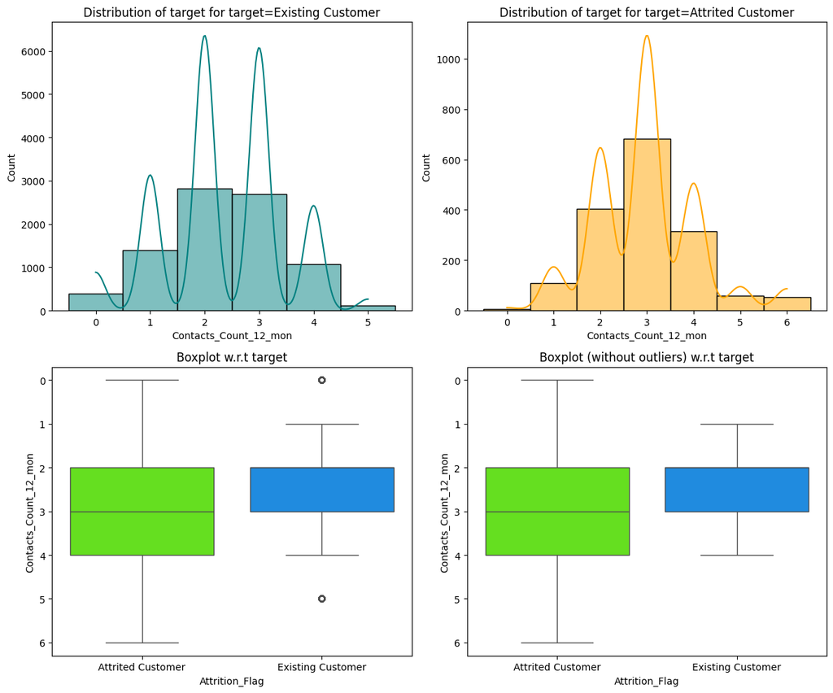

```python
distribution_plot_wrt_target(data, "Contacts_Count_12_mon", "Attrition_Flag")
```

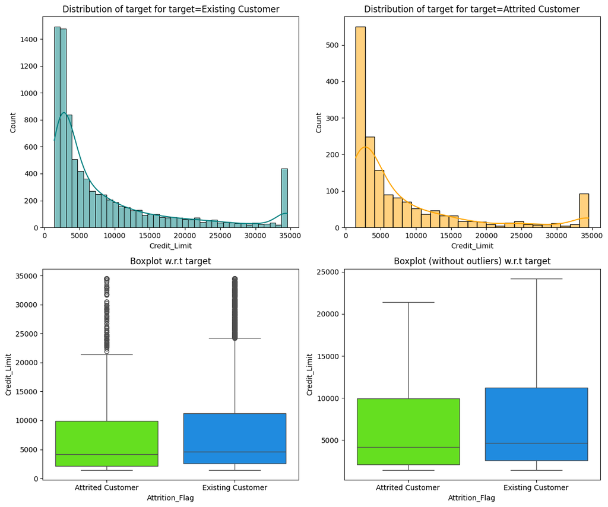

```python
distribution_plot_wrt_target(data, "Credit_Limit", "Attrition_Flag")
```

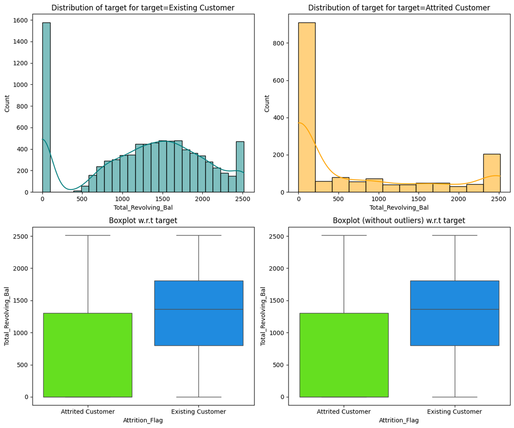

```python
distribution_plot_wrt_target(data, "Total_Revolving_Bal", "Attrition_Flag")
```

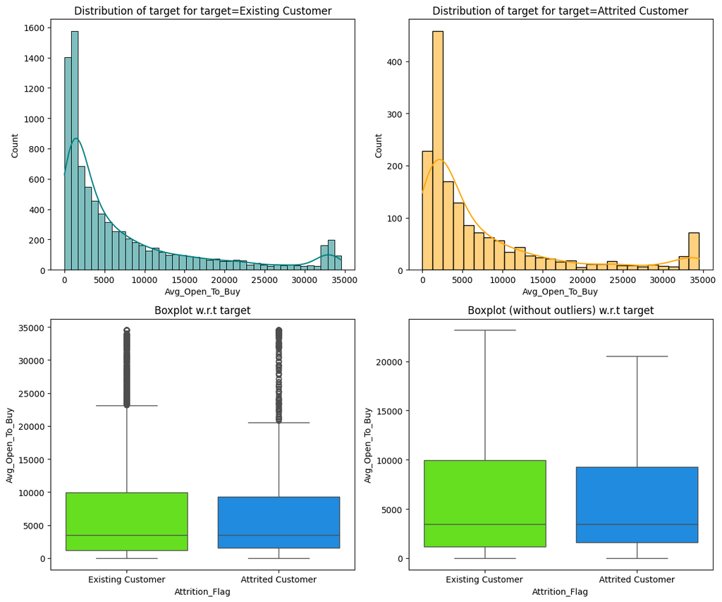

```python
distribution_plot_wrt_target(data, "Avg_Open_To_Buy", "Attrition_Flag")
```

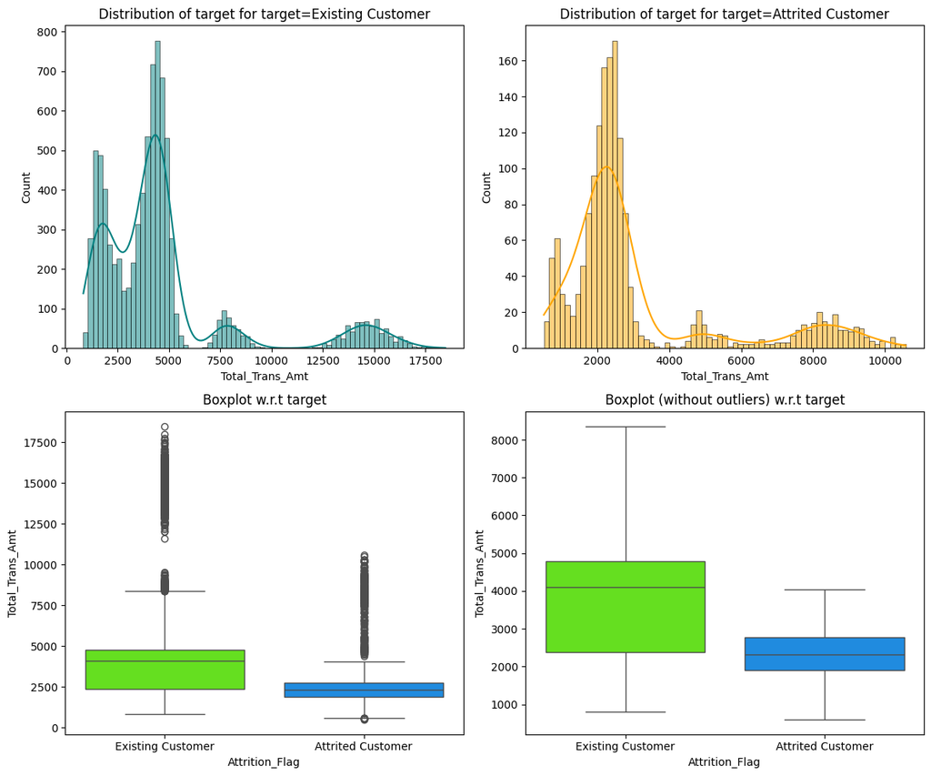

```python
distribution_plot_wrt_target(data, "Total_Trans_Amt", "Attrition_Flag")
```

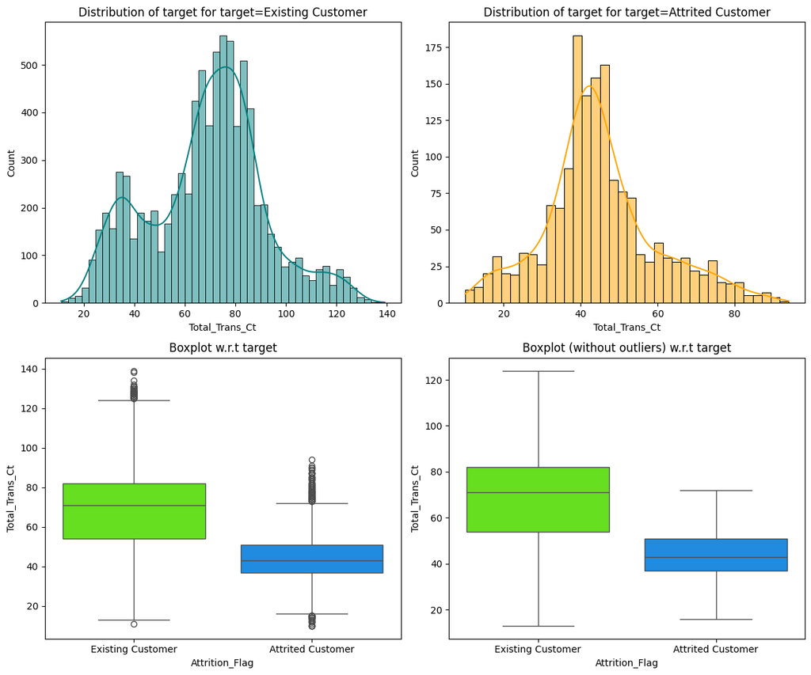

```python
distribution_plot_wrt_target(data, "Total_Trans_Ct", "Attrition_Flag")
```

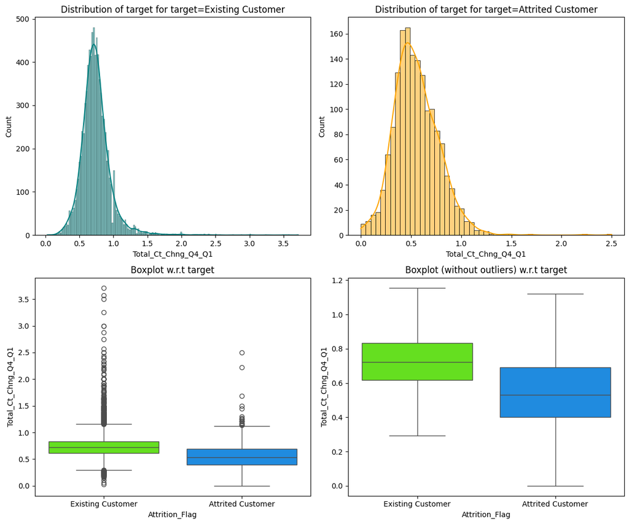

```python
distribution_plot_wrt_target(data, "Total_Ct_Chng_Q4_Q1", "Attrition_Flag")
```

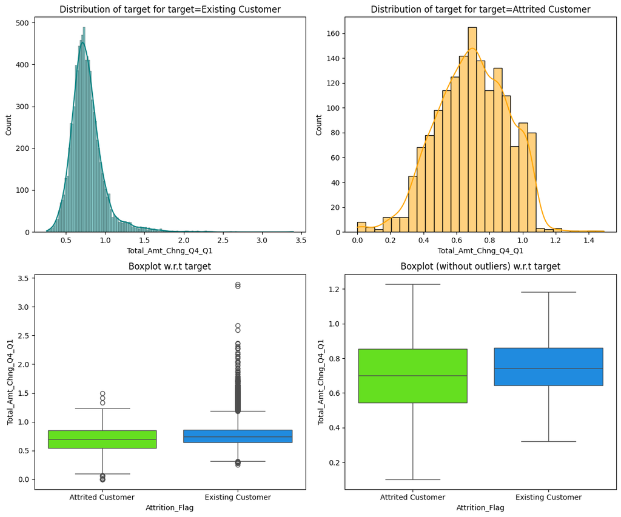

```python
distribution_plot_wrt_target(data, "Total_Amt_Chng_Q4_Q1", "Attrition_Flag")
```

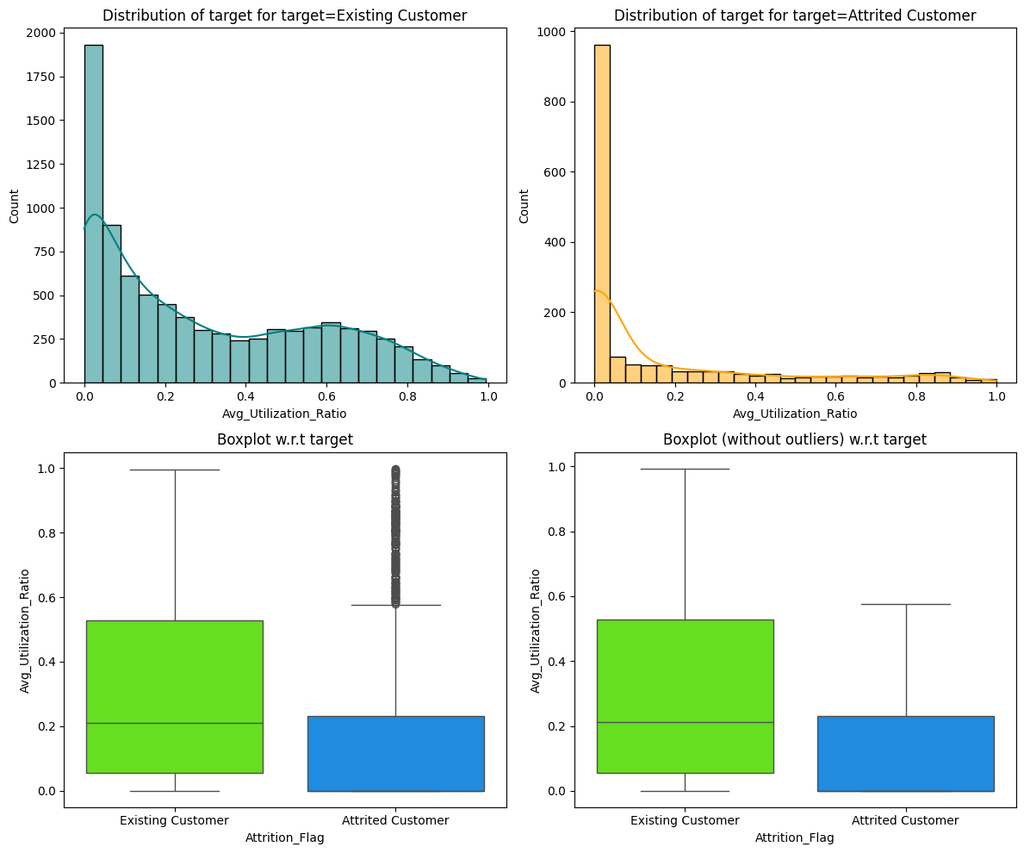

```python
distribution_plot_wrt_target(data, "Avg_Utilization_Ratio", "Attrition_Flag")
```

**Observations of Distribution with target Variable which will be insighful during making business recommendations**

-Customer Age : Most Attrited Customers in Early 40's to Early 50's age

- Income Category - Most(Over 600 ) attrited in less than 40K category and Others have similar tendency, however Income Categorty 120+ attrites less

  -Education_Level: Lesser attrition in Doctors and Post Grad. Rest all attrite more, Grad and High School level the most

  -Card Category : Blue being the most popular has the maximum attrition as well

  -Months_on_book : Most Customers who left we between 32-40 months on book

  -Contacts_count : Observed that the maximum attrition of customers contact count 2-3

  -Credit_Limit : Mosr Attrition between 2-10000 Credit Limit

  -Total Revoving Balance : Most Customers who left have this low between 2-1300

  -Average open to buy - Customers leavinh have Open to buy bwteeb 2000-10000

  -Total Transaction Amount : Customers with lesser transaction amount between 1800-2800 are more likely to attrite

  -Total Transction Count : Customers having total transaction count bewteen 35-50 are more likely to leave

  -Total_Ct_Chng_Q4_Q1 : 0.4-0.7 ratio customers show more attrition

  -Total_Amt_Chng_Q4_Q1 -0.5- 0.9 ratio Customers show attrition

  -Avg_Utilization_Ratio : Customers having utilization Ration b/w 0 to 0.25 will tend to leave

## Data Pre-processing

```python
# Keep a data copy before Data-Preprocessing for Model building
data1=data.copy()
```

```python
# we need to pass numerical values for each categorical column with missing data for imputation so we will label encode them

Education_Level = {
             "Uneducated": 0,
             "High School": 1,
             "College": 2,
             "Graduate": 3,
             "Post-Graduate":4,
             "Doctorate":5}
data1["Education_Level"] = data1["Education_Level"].map(Education_Level)

Marital_Status = {
                  "Divorced": 0, "Single": 1, "Married": 2}
data1["Marital_Status"] = data1["Marital_Status"].map(Marital_Status)
```

```python
data1.head()
```

|  | Attrition_Flag | Customer_Age | Gender | Dependent_count | Education_Level | Marital_Status | Income_Category | Card_Category | Months_on_book | Total_Relationship_Count | Months_Inactive_12_mon | Contacts_Count_12_mon | Credit_Limit | Total_Revolving_Bal | Avg_Open_To_Buy | Total_Amt_Chng_Q4_Q1 | Total_Trans_Amt | Total_Trans_Ct | Total_Ct_Chng_Q4_Q1 | Avg_Utilization_Ratio |
| --- | --- | --- | --- | --- | --- | --- | --- | --- | --- | --- | --- | --- | --- | --- | --- | --- | --- | --- | --- | --- |
| 0 | Existing Customer | 45 | M | 3 | 1 | 2 | $60K - $80K | Blue | 39 | 5 | 1 | 3 | 12691.0 | 777 | 11914.0 | 1.335 | 1144 | 42 | 1.625 | 0.061 |
| 1 | Existing Customer | 49 | F | 5 | 3 | 1 | Less than $40K | Blue | 44 | 6 | 1 | 2 | 8256.0 | 864 | 7392.0 | 1.541 | 1291 | 33 | 3.714 | 0.105 |
| 2 | Existing Customer | 51 | M | 3 | 3 | 2 | $80K - $120K | Blue | 36 | 4 | 1 | 0 | 3418.0 | 0 | 3418.0 | 2.594 | 1887 | 20 | 2.333 | 0.000 |
| 3 | Existing Customer | 40 | F | 4 | 1 | NaN | Less than $40K | Blue | 34 | 3 | 4 | 1 | 3313.0 | 2517 | 796.0 | 1.405 | 1171 | 20 | 2.333 | 0.760 |
| 4 | Existing Customer | 40 | M | 3 | 0 | 2 | $60K - $80K | Blue | 21 | 5 | 1 | 0 | 4716.0 | 0 | 4716.0 | 2.175 | 816 | 28 | 2.500 | 0.000 |

```python
data1.info()
```

```
<class 'pandas.core.frame.DataFrame'>
RangeIndex: 10127 entries, 0 to 10126
Data columns (total 20 columns):
 #   Column                    Non-Null Count  Dtype
---  ------                    --------------  -----
 0   Attrition_Flag            10127 non-null  category
 1   Customer_Age              10127 non-null  int64
 2   Gender                    10127 non-null  category
 3   Dependent_count           10127 non-null  category
 4   Education_Level           8608 non-null   category
 5   Marital_Status            9378 non-null   category
 6   Income_Category           10127 non-null  category
 7   Card_Category             10127 non-null  category
 8   Months_on_book            10127 non-null  int64
 9   Total_Relationship_Count  10127 non-null  category
 10  Months_Inactive_12_mon    10127 non-null  category
 11  Contacts_Count_12_mon     10127 non-null  category
 12  Credit_Limit              10127 non-null  float64
 13  Total_Revolving_Bal       10127 non-null  int64
 14  Avg_Open_To_Buy           10127 non-null  float64
 15  Total_Amt_Chng_Q4_Q1      10127 non-null  float64
 16  Total_Trans_Amt           10127 non-null  int64
 17  Total_Trans_Ct            10127 non-null  int64
 18  Total_Ct_Chng_Q4_Q1       10127 non-null  float64
 19  Avg_Utilization_Ratio     10127 non-null  float64
dtypes: category(10), float64(5), int64(5)
memory usage: 892.3 KB
```

## Feature Egineering

- Avg Utilisation Ratio is Avg customer Spend /Available credit. We can use this calcute Avg Custmer Spend and Add a new column to help with model buiding and generating insights using the formula

  *Avg Spend = Avg Utilisation Ratio X Credit Limit*

```python
#Add a AvgSpend column using Credit limit and Avg utilisation ratio
data1['Avg_Spend'] = data1['Avg_Utilization_Ratio'] * data1['Credit_Limit']
```

```python
#validate the column and its statistics
data1.head()
```

|  | Attrition_Flag | Customer_Age | Gender | Dependent_count | Education_Level | Marital_Status | Income_Category | Card_Category | Months_on_book | Total_Relationship_Count | ... | Contacts_Count_12_mon | Credit_Limit | Total_Revolving_Bal | Avg_Open_To_Buy | Total_Amt_Chng_Q4_Q1 | Total_Trans_Amt | Total_Trans_Ct | Total_Ct_Chng_Q4_Q1 | Avg_Utilization_Ratio | Avg_Spend |
| --- | --- | --- | --- | --- | --- | --- | --- | --- | --- | --- | --- | --- | --- | --- | --- | --- | --- | --- | --- | --- | --- |
| 0 | Existing Customer | 45 | M | 3 | 1 | 2 | $60K - $80K | Blue | 39 | 5 | ... | 3 | 12691.0 | 777 | 11914.0 | 1.335 | 1144 | 42 | 1.625 | 0.061 | 774.151 |
| 1 | Existing Customer | 49 | F | 5 | 3 | 1 | Less than $40K | Blue | 44 | 6 | ... | 2 | 8256.0 | 864 | 7392.0 | 1.541 | 1291 | 33 | 3.714 | 0.105 | 866.880 |
| 2 | Existing Customer | 51 | M | 3 | 3 | 2 | $80K - $120K | Blue | 36 | 4 | ... | 0 | 3418.0 | 0 | 3418.0 | 2.594 | 1887 | 20 | 2.333 | 0.000 | 0.000 |
| 3 | Existing Customer | 40 | F | 4 | 1 | NaN | Less than $40K | Blue | 34 | 3 | ... | 1 | 3313.0 | 2517 | 796.0 | 1.405 | 1171 | 20 | 2.333 | 0.760 | 2517.880 |
| 4 | Existing Customer | 40 | M | 3 | 0 | 2 | $60K - $80K | Blue | 21 | 5 | ... | 0 | 4716.0 | 0 | 4716.0 | 2.175 | 816 | 28 | 2.500 | 0.000 | 0.000 |

5 rows × 21 columns

```python
data1['Avg_Spend'].describe()
```

|  | Avg_Spend |
| --- | --- |
| count | 10127.000000 |
| mean | 1162.823206 |
| std | 815.018463 |
| min | 0.000000 |
| 25% | 360.094150 |
| 50% | 1277.092000 |
| 75% | 1784.037000 |
| max | 2531.749000 |

**dtype:** float64

```python
#Data Frame befor Preparation for Modeling
data1.info()
```

```
<class 'pandas.core.frame.DataFrame'>
RangeIndex: 10127 entries, 0 to 10126
Data columns (total 21 columns):
 #   Column                    Non-Null Count  Dtype
---  ------                    --------------  -----
 0   Attrition_Flag            10127 non-null  category
 1   Customer_Age              10127 non-null  int64
 2   Gender                    10127 non-null  category
 3   Dependent_count           10127 non-null  category
 4   Education_Level           8608 non-null   category
 5   Marital_Status            9378 non-null   category
 6   Income_Category           10127 non-null  category
 7   Card_Category             10127 non-null  category
 8   Months_on_book            10127 non-null  int64
 9   Total_Relationship_Count  10127 non-null  category
 10  Months_Inactive_12_mon    10127 non-null  category
 11  Contacts_Count_12_mon     10127 non-null  category
 12  Credit_Limit              10127 non-null  float64
 13  Total_Revolving_Bal       10127 non-null  int64
 14  Avg_Open_To_Buy           10127 non-null  float64
 15  Total_Amt_Chng_Q4_Q1      10127 non-null  float64
 16  Total_Trans_Amt           10127 non-null  int64
 17  Total_Trans_Ct            10127 non-null  int64
 18  Total_Ct_Chng_Q4_Q1       10127 non-null  float64
 19  Avg_Utilization_Ratio     10127 non-null  float64
 20  Avg_Spend                 10127 non-null  float64
dtypes: category(10), float64(6), int64(5)
memory usage: 971.4 KB
```

## Data Preparation for Modelling

```python
X = data1.drop(["Attrition_Flag"], axis=1)
y = data1["Attrition_Flag"].apply(lambda x: 1 if x == "Attrited Customer" else 0)
```

```python
# Splitting data into training, validation and test set:
# first we split data into 2 parts, say temporary and test

X_temp, X_test, y_temp, y_test = train_test_split(
    X, y, test_size=0.2, random_state=1, stratify=y
)

# then we split the temporary set into train and validation

X_train, X_val, y_train, y_val = train_test_split(
    X_temp, y_temp, test_size=0.25, random_state=1, stratify=y_temp
)
print(X_train.shape, X_val.shape, X_test.shape)
```

```
(6075, 20) (2026, 20) (2026, 20)
```

```python
print("Number of rows in train data =", X_train.shape[0])
print("Number of rows in validation data =", X_val.shape[0])
print("Number of rows in test data =", X_test.shape[0])
```

```
Number of rows in train data = 6075
Number of rows in validation data = 2026
Number of rows in test data = 2026
```

```python
cat_cols = list(X_train.select_dtypes(include='category').columns)
print("Categorical Columns =",cat_cols)
num_cols = list(X_train.select_dtypes(include=['int', 'float']).columns)
print("Numerical Columns =",num_cols)
```

```
Categorical Columns = ['Gender', 'Dependent_count', 'Education_Level', 'Marital_Status', 'Income_Category', 'Card_Category', 'Total_Relationship_Count', 'Months_Inactive_12_mon', 'Contacts_Count_12_mon']
Numerical Columns = ['Customer_Age', 'Months_on_book', 'Credit_Limit', 'Total_Revolving_Bal', 'Avg_Open_To_Buy', 'Total_Amt_Chng_Q4_Q1', 'Total_Trans_Amt', 'Total_Trans_Ct', 'Total_Ct_Chng_Q4_Q1', 'Avg_Utilization_Ratio', 'Avg_Spend']
```

## Missing value imputation

```python
import pandas as pd
from sklearn.impute import SimpleImputer

# Get list of categorical and numerical columns
cat_cols = list(X_train.select_dtypes(include='category').columns)

# Impute categorical columns
cat_imputer = SimpleImputer(strategy='most_frequent')
X_train[cat_cols] = cat_imputer.fit_transform(X_train[cat_cols])
X_val[cat_cols] = cat_imputer.transform(X_val[cat_cols])
X_test[cat_cols] = cat_imputer.transform(X_test[cat_cols])
```

```python
# Checking that no column has missing values in train, validation or test sets
print(X_train.isna().sum())
print("-" * 30)
print(X_val.isna().sum())
print("-" * 30)
print(X_test.isna().sum())
```

```
Customer_Age                0
Gender                      0
Dependent_count             0
Education_Level             0
Marital_Status              0
Income_Category             0
Card_Category               0
Months_on_book              0
Total_Relationship_Count    0
Months_Inactive_12_mon      0
Contacts_Count_12_mon       0
Credit_Limit                0
Total_Revolving_Bal         0
Avg_Open_To_Buy             0
Total_Amt_Chng_Q4_Q1        0
Total_Trans_Amt             0
Total_Trans_Ct              0
Total_Ct_Chng_Q4_Q1         0
Avg_Utilization_Ratio       0
Avg_Spend                   0
dtype: int64
------------------------------
Customer_Age                0
Gender                      0
Dependent_count             0
Education_Level             0
Marital_Status              0
Income_Category             0
Card_Category               0
Months_on_book              0
Total_Relationship_Count    0
Months_Inactive_12_mon      0
Contacts_Count_12_mon       0
Credit_Limit                0
Total_Revolving_Bal         0
Avg_Open_To_Buy             0
Total_Amt_Chng_Q4_Q1        0
Total_Trans_Amt             0
Total_Trans_Ct              0
Total_Ct_Chng_Q4_Q1         0
```

[output cut: 10 more lines]

```
Card_Category               0
Months_on_book              0
Total_Relationship_Count    0
Months_Inactive_12_mon      0
Contacts_Count_12_mon       0
Credit_Limit                0
Total_Revolving_Bal         0
Avg_Open_To_Buy             0
Total_Amt_Chng_Q4_Q1        0
Total_Trans_Amt             0
Total_Trans_Ct              0
Total_Ct_Chng_Q4_Q1         0
Avg_Utilization_Ratio       0
Avg_Spend                   0
dtype: int64
```

# Reverse Mapping for Encoded Variables

```python
## Function to inverse the encoding
def inverse_mapping(x, y):
    inv_dict = {v: k for k, v in x.items()}
    X_train[y] = np.round(X_train[y]).map(inv_dict).astype("category")
    X_val[y] = np.round(X_val[y]).map(inv_dict).astype("category")
    X_test[y] = np.round(X_test[y]).map(inv_dict).astype("category")
```

```python
inverse_mapping(Education_Level, "Education_Level")
inverse_mapping(Marital_Status, "Marital_Status")
```

```python
# Convert categorical columns back to category type
#This step is done because it was observed that running the simple imputer on categorical columns were changing the datatype
# of categorical columns without missing value to object type.Inverse mapping took care of the label encoded columns for which we defined dictionary,
#this is for the remaining categorical columns
for col in cat_cols:
   X_train[col] = X_train[col].astype('category')
   X_val[col] = X_val[col].astype('category')
   X_test[col] = X_test[col].astype('category')
```

# Checking inverse mapped values/categories

#### `Train Dataset`

```python
cols = X_train.select_dtypes("category")
for i in cols.columns:
    print(X_train[i].value_counts())
    print("*" * 30)
```

```
Gender
F    3193
M    2882
Name: count, dtype: int64
Dependent_count
2    1615
3    1605
1    1103
4     947
0     547
5     258
Name: count, dtype: int64
Education_Level
Graduate         2782
High School      1228
Uneducated        881
College           618
Post-Graduate     312
Doctorate         254
Name: count, dtype: int64
Marital_Status
Married     3276
Single      2369
Divorced     430
Name: count, dtype: int64
Income_Category
Less than $40K    2129
$40K - $60K       1059
$80K - $120K       953
$60K - $80K        831
Undisclosed        654
$120K +            449
Name: count, dtype: int64
Card_Category
Blue        5655
Silver       339
Gold          69
Platinum      12
Name: count, dtype: int64
Total_Relationship_Count
```

[output cut: 10 more lines]

```
1    1348
4     272
5     110
6      69
0      19
Name: count, dtype: int64
Contacts_Count_12_mon
3    2011
2    1943
1     908
4     833
0     241
5     104
6      35
Name: count, dtype: int64
```

#### `Validation Dataset`

```python
cols = X_val.select_dtypes(include=["category"])
for i in cols.columns:
    print(X_val[i].value_counts())
    print("*" * 30)
```

```
Gender
F    1095
M     931
Name: count, dtype: int64
Dependent_count
3    572
2    520
1    364
4    315
0    169
5     86
Name: count, dtype: int64
Education_Level
Graduate         917
High School      404
Uneducated       306
College          199
Post-Graduate    101
Doctorate         99
Name: count, dtype: int64
Marital_Status
Married     1100
Single       770
Divorced     156
Name: count, dtype: int64
Income_Category
Less than $40K    736
$40K - $60K       361
$80K - $120K      293
$60K - $80K       279
Undisclosed       221
$120K +           136
Name: count, dtype: int64
Card_Category
Blue        1905
Silver        97
Gold          21
Platinum       3
Name: count, dtype: int64
Total_Relationship_Count
```

[output cut: 10 more lines]

```
1    464
4     84
5     33
6     31
0      6
Name: count, dtype: int64
Contacts_Count_12_mon
3    706
2    650
4    279
1    269
0     76
5     37
6      9
Name: count, dtype: int64
```

#### `Test Dataset`

```python
cols = X_test.select_dtypes(include=["category"])
for i in cols.columns:
    print(X_test[i].value_counts())
    print("*" * 30)
```

```
Gender
F    1070
M     956
Name: count, dtype: int64
Dependent_count
3    555
2    520
1    371
4    312
0    188
5     80
Name: count, dtype: int64
Education_Level
Graduate         948
High School      381
Uneducated       300
College          196
Post-Graduate    103
Doctorate         98
Name: count, dtype: int64
Marital_Status
Married     1060
Single       804
Divorced     162
Name: count, dtype: int64
Income_Category
Less than $40K    696
$40K - $60K       370
$60K - $80K       292
$80K - $120K      289
Undisclosed       237
$120K +           142
Name: count, dtype: int64
Card_Category
Blue        1876
Silver       119
Gold          26
Platinum       5
Name: count, dtype: int64
Total_Relationship_Count
```

[output cut: 10 more lines]

```
1    421
4     79
5     35
6     24
0      4
Name: count, dtype: int64
Contacts_Count_12_mon
3    663
2    634
1    322
4    280
0     82
5     35
6     10
Name: count, dtype: int64
```

### Creating Dummy Variables

```python
X_train = pd.get_dummies(X_train, drop_first=True)
X_train = X_train.astype(float)

X_val = pd.get_dummies(X_val, drop_first=True)
X_val = X_val.astype(float)

X_test = pd.get_dummies(X_test, drop_first=True)
X_test = X_test.astype(float)

print(X_train.shape, X_val.shape, X_test.shape)
```

```
(6075, 49) (2026, 49) (2026, 49)
```

## Model Building

### Model evaluation criterion

The nature of predictions made by the classification model will translate as follows:

-True positives (TP) are customers who will leave Credit card correctly predicted by the model.

-False negatives (FN) are customers who will leave Credit Card but were not detected by model.

-False positives (FP) are wrongly identified customers who will leave the Credit Card where the actually do not leave.

Which metric to optimize?

We need to choose the metric which will ensure that the maximum number of customers who will leave Credit card are predicted correctly by the model. We would want **Recall** to be maximized as greater the Recall, the higher the chances of minimizing false negatives. We want to minimize false negatives because if a model predicts that a customer will mot leave credit card when he actually leaves, it will increase Bank Revenue losses . We also want to minimize False Positives, thereby having good precision .

In that context, **Along with maximum reacall, good F1 score** will be the criteria to evaluate ensuring both false negatives and false positives are mimimized.

**Let's define a function to output different metrics (including recall) on the train and test set and a function to show confusion matrix so that we do not have to use the same code repetitively while evaluating models.**

```python
# defining a function to compute different metrics to check performance of a classification model built using sklearn
def model_performance_classification_sklearn(model, predictors, target):
    """
    Function to compute different metrics to check classification model performance

    model: classifier
    predictors: independent variables
    target: dependent variable
    """

    # predicting using the independent variables
    pred = model.predict(predictors)

    acc = accuracy_score(target, pred)  # to compute Accuracy
    recall = recall_score(target, pred)  # to compute Recall
    precision = precision_score(target, pred)  # to compute Precision
    f1 = f1_score(target, pred)  # to compute F1-score

    # creating a dataframe of metrics
    df_perf = pd.DataFrame(
        {
            "Accuracy": acc,
            "Recall": recall,
            "Precision": precision,
            "F1": f1

        },
        index=[0],
    )

    return df_perf
```